# examples_0415

Now we can form another **right triangle**, using $B$, the height, and the desired length, which we can call $D$.

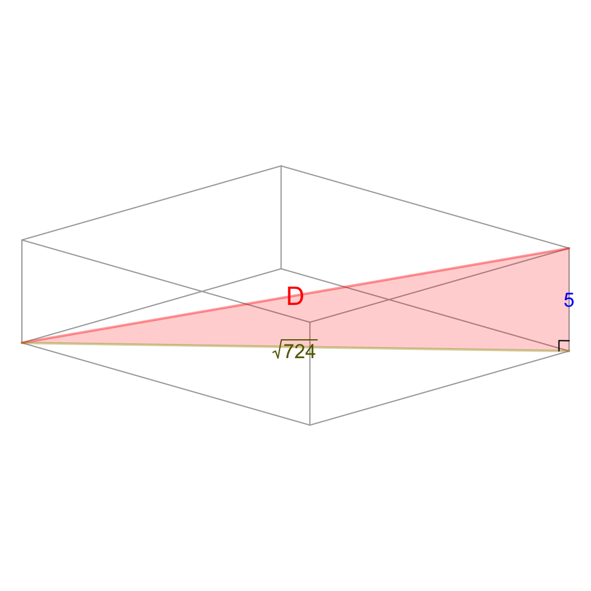

$$D ~=~
\sqrt{5^2+\left(\sqrt{724}\right)^2}$$
$$D ~=~ \sqrt{25+724}$$
$$D ~=~ \sqrt{749}$$
$$D ~\approx~ 27.3678644$$

If you were super observant, you might have picked up on a shortcut. Basically, in 3D, [the distance](https://en.wikipedia.org/wiki/Distance#Straight-line_or_Euclidean_distance) between 2 points is:

$$D~=~\sqrt{(\Delta x)^2+(\Delta
y)^2+(\Delta z)^2}$$

where $\Delta x=x_2-x_1$ and $\Delta y=y_2-y_1$ and $\Delta z=z_2-z_1$.

A [right rectangular prism](https://en.m.wikipedia.org/wiki/Rectangular_cuboid) is 19 inches wide, 15 inches deep, and 10 inches tall.

What is the distance between opposite corners?

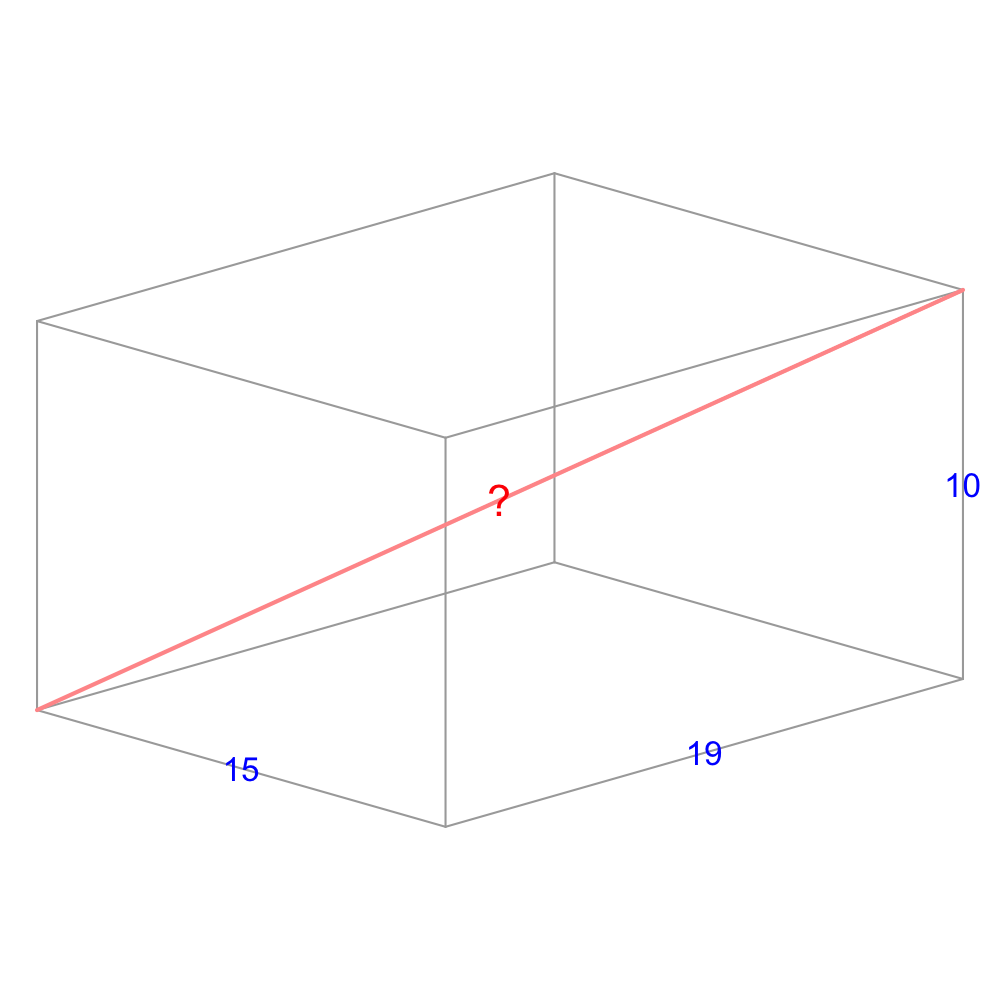

Please be accurate within $\pm$ 0.01 of the exact answer.

Let's use Pythagorean Theorem. This is possible because all angles are 90 degrees. To do this, we can first find the length of a diagonal across the bottom. Let's call it $B$.

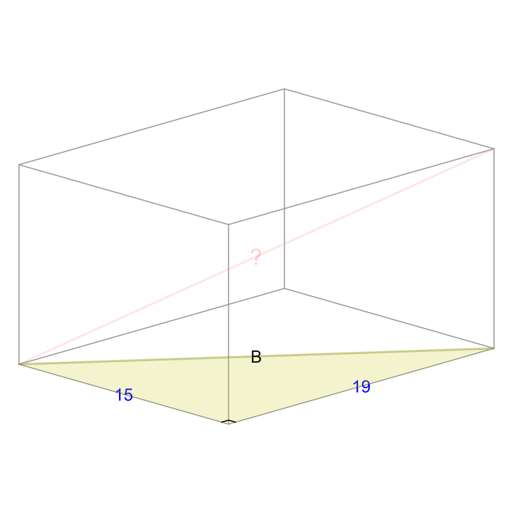

$$B~=~\sqrt{19^2+15^2}~=~\sqrt{586}
~\approx~24.2074369$$

Now we can form another **right triangle**, using $B$, the height, and the desired length, which we can call $D$.

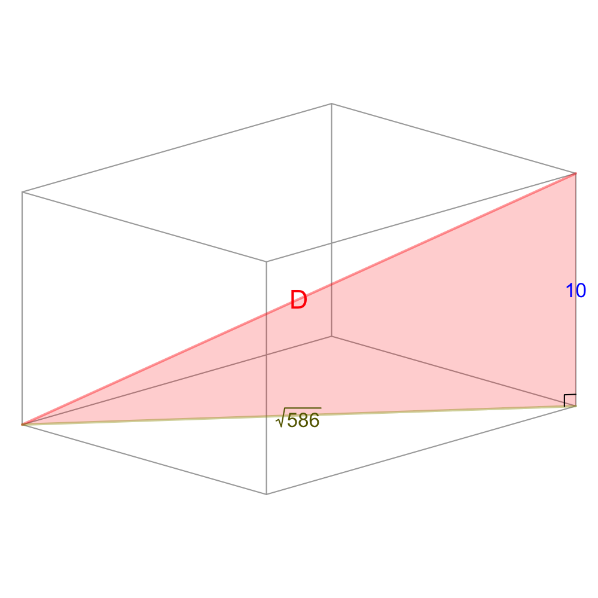

$$D ~=~
\sqrt{10^2+\left(\sqrt{586}\right)^2}$$
$$D ~=~ \sqrt{100+586}$$
$$D ~=~ \sqrt{686}$$
$$D ~\approx~ 26.1916017$$

If you were super observant, you might have picked up on a shortcut. Basically, in 3D, [the distance](https://en.wikipedia.org/wiki/Distance#Straight-line_or_Euclidean_distance) between 2 points is:

$$D~=~\sqrt{(\Delta x)^2+(\Delta
y)^2+(\Delta z)^2}$$

where $\Delta x=x_2-x_1$ and $\Delta y=y_2-y_1$ and $\Delta z=z_2-z_1$.

A [right rectangular prism](https://en.m.wikipedia.org/wiki/Rectangular_cuboid) is 17 inches wide, 11 inches deep, and 15 inches tall.

What is the distance between opposite corners?

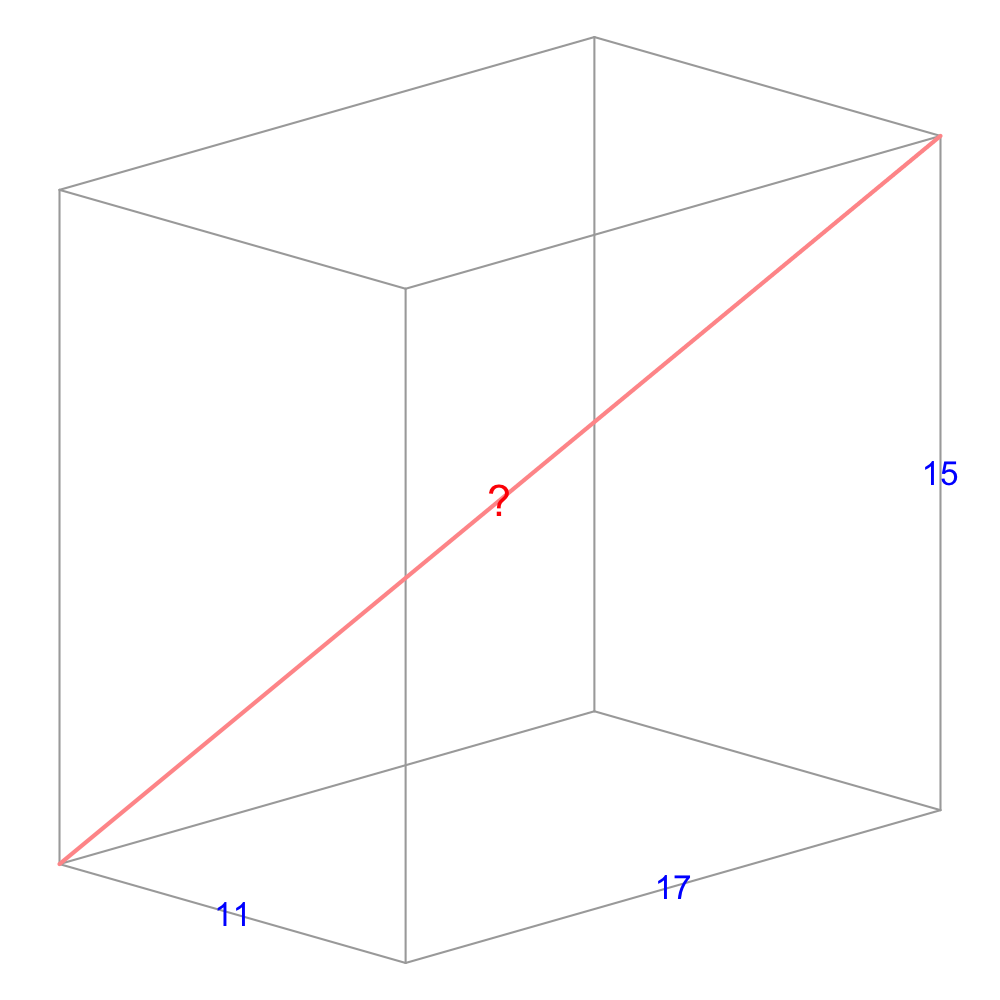

Please be accurate within $\pm$ 0.01 of the exact answer.

Let's use Pythagorean Theorem. This is possible because all angles are 90 degrees. To do this, we can first find the length of a diagonal across the bottom. Let's call it $B$.

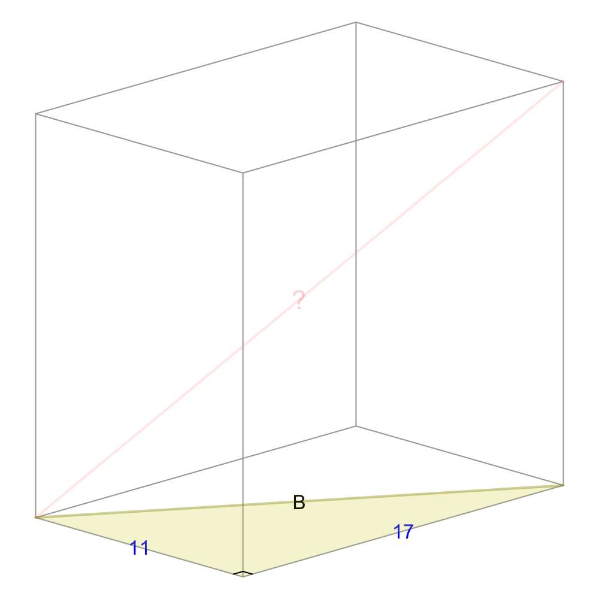

$$B~=~\sqrt{17^2+11^2}~=~\sqrt{410}
~\approx~20.2484567$$

Now we can form another **right triangle**, using $B$, the height, and the desired length, which we can call $D$.

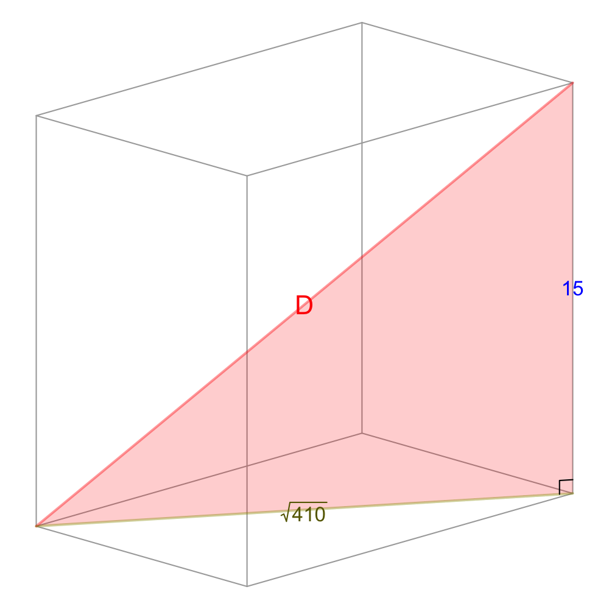

$$D ~=~
\sqrt{15^2+\left(\sqrt{410}\right)^2}$$
$$D ~=~ \sqrt{225+410}$$
$$D ~=~ \sqrt{635}$$
$$D ~\approx~ 25.1992063$$

If you were super observant, you might have picked up on a shortcut. Basically, in 3D, [the distance](https://en.wikipedia.org/wiki/Distance#Straight-line_or_Euclidean_distance) between 2 points is:

$$D~=~\sqrt{(\Delta x)^2+(\Delta
y)^2+(\Delta z)^2}$$

where $\Delta x=x_2-x_1$ and $\Delta y=y_2-y_1$ and $\Delta z=z_2-z_1$.

A [right rectangular prism](https://en.m.wikipedia.org/wiki/Rectangular_cuboid) is 20 inches wide, 11 inches deep, and 5 inches tall.

What is the distance between opposite corners?

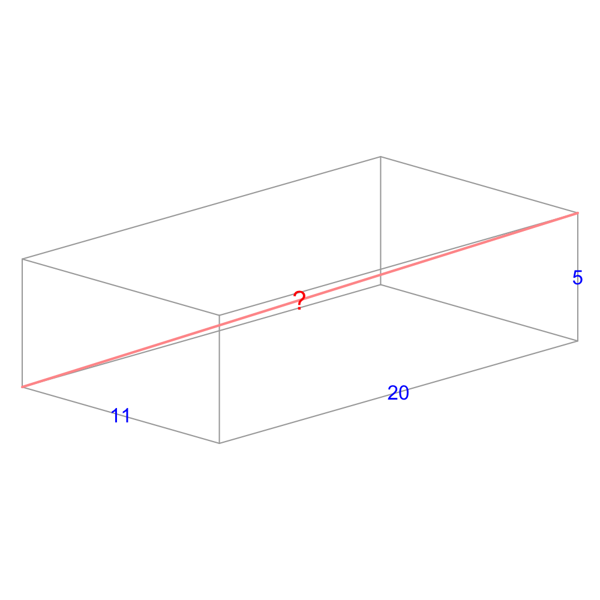

Please be accurate within $\pm$ 0.01 of the exact answer.

Let's use Pythagorean Theorem. This is possible because all angles are 90 degrees. To do this, we can first find the length of a diagonal across the bottom. Let's call it $B$.

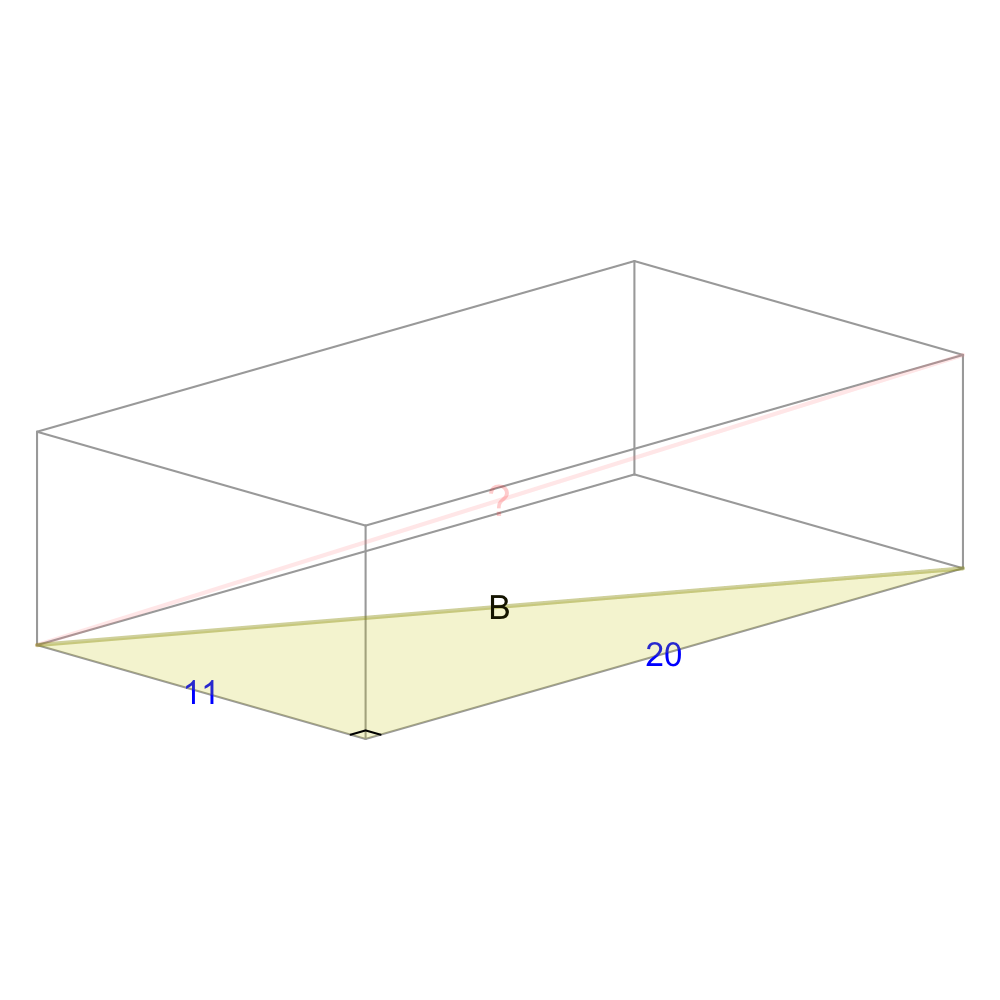

$$B~=~\sqrt{20^2+11^2}~=~\sqrt{521}
~\approx~22.8254244$$

Now we can form another **right triangle**, using $B$, the height, and the desired length, which we can call $D$.

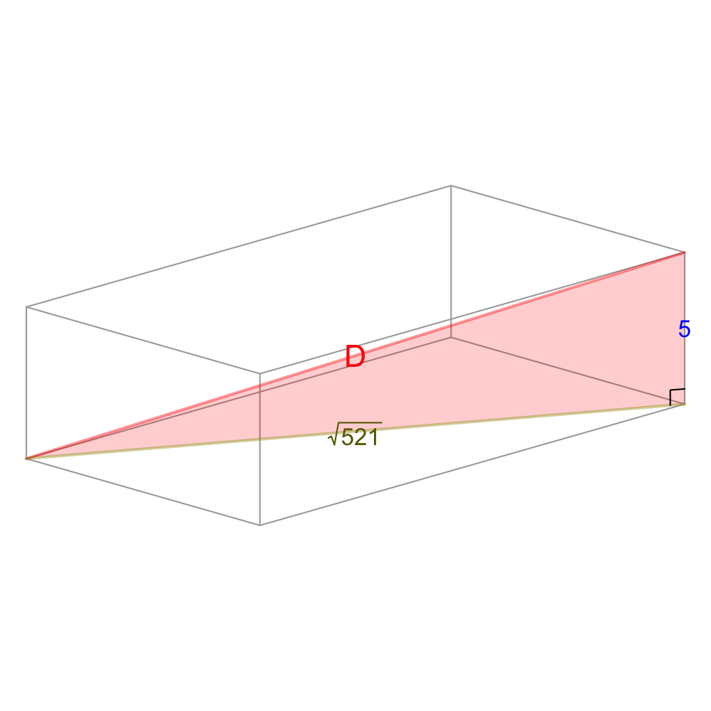

$$D ~=~
\sqrt{5^2+\left(\sqrt{521}\right)^2}$$
$$D ~=~ \sqrt{25+521}$$
$$D ~=~ \sqrt{546}$$
$$D ~\approx~ 23.3666429$$

If you were super observant, you might have picked up on a shortcut. Basically, in 3D, [the distance](https://en.wikipedia.org/wiki/Distance#Straight-line_or_Euclidean_distance) between 2 points is:

$$D~=~\sqrt{(\Delta x)^2+(\Delta
y)^2+(\Delta z)^2}$$

where $\Delta x=x_2-x_1$ and $\Delta y=y_2-y_1$ and $\Delta z=z_2-z_1$.

A [right rectangular prism](https://en.m.wikipedia.org/wiki/Rectangular_cuboid) is 10 inches wide, 9 inches deep, and 18 inches tall.

What is the distance between opposite corners?

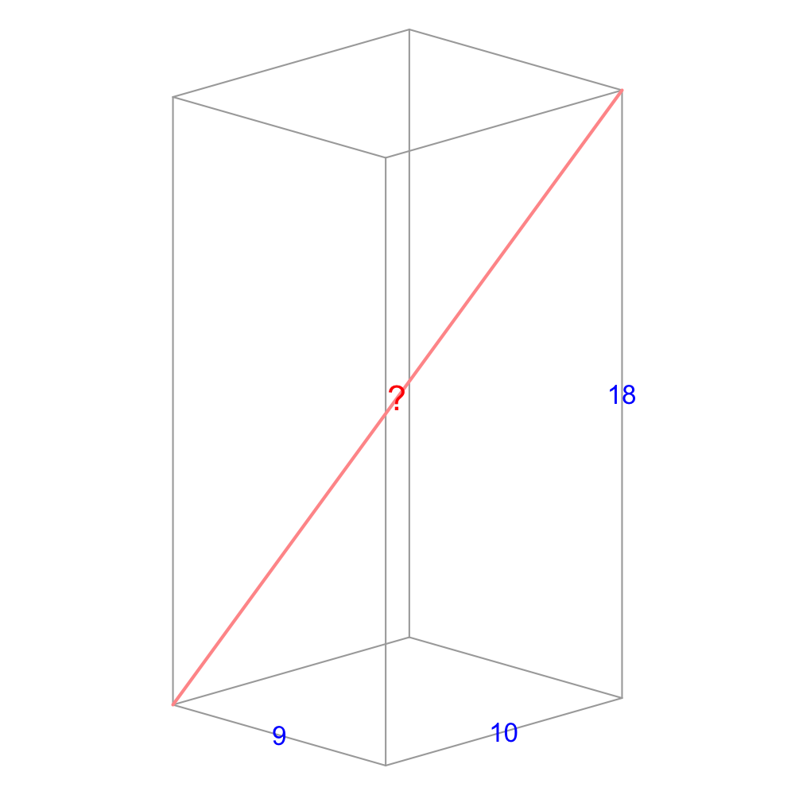

Please be accurate within $\pm$ 0.01 of the exact answer.

Let's use Pythagorean Theorem. This is possible because all angles are 90 degrees. To do this, we can first find the length of a diagonal across the bottom. Let's call it $B$.

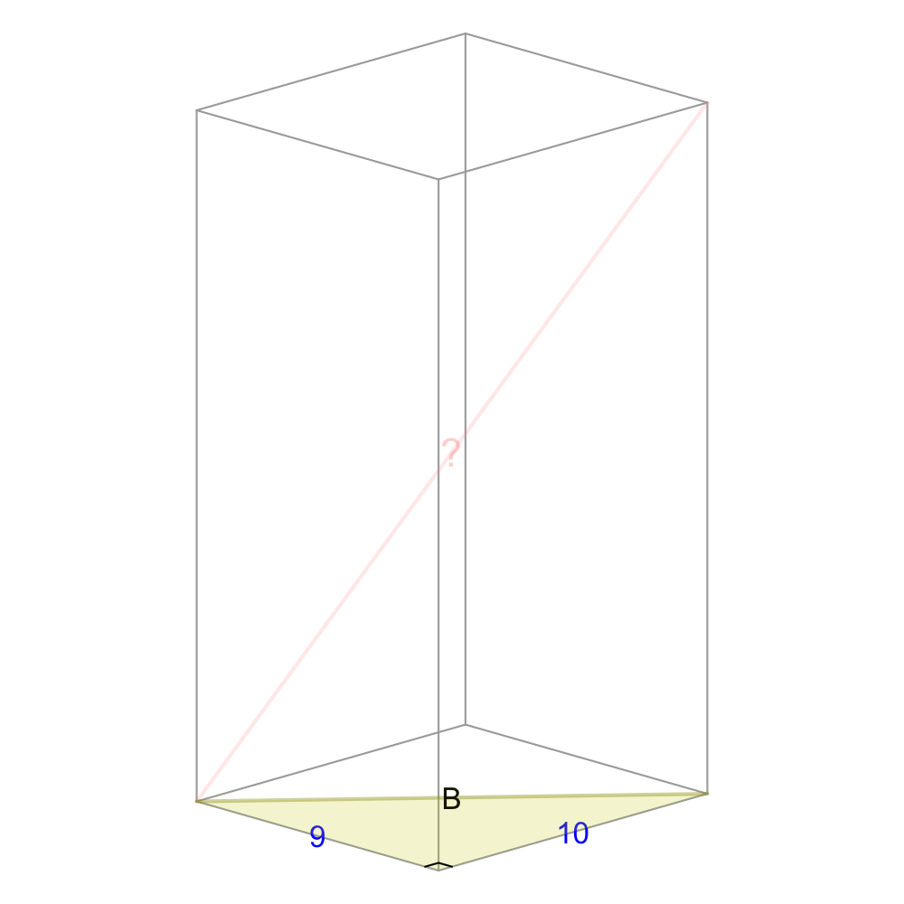

$$B~=~\sqrt{10^2+9^2}~=~\sqrt{181}
~\approx~13.453624$$

Now we can form another **right triangle**, using $B$, the height, and the desired length, which we can call $D$.

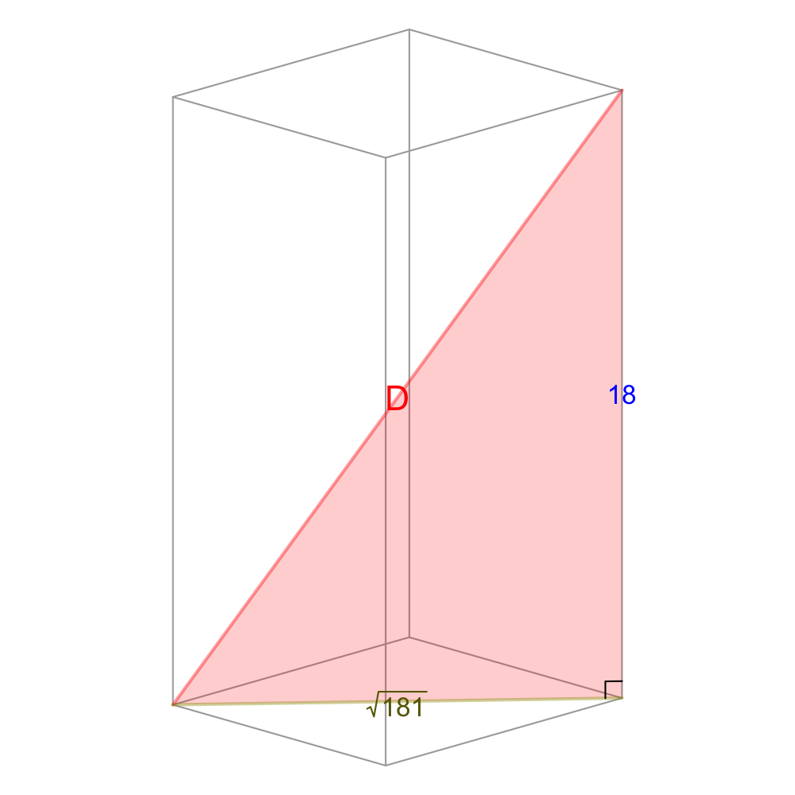

$$D ~=~
\sqrt{18^2+\left(\sqrt{181}\right)^2}$$
$$D ~=~ \sqrt{324+181}$$
$$D ~=~ \sqrt{505}$$
$$D ~\approx~ 22.4722051$$

If you were super observant, you might have picked up on a shortcut. Basically, in 3D, [the distance](https://en.wikipedia.org/wiki/Distance#Straight-line_or_Euclidean_distance) between 2 points is:

$$D~=~\sqrt{(\Delta x)^2+(\Delta
y)^2+(\Delta z)^2}$$

where $\Delta x=x_2-x_1$ and $\Delta y=y_2-y_1$ and $\Delta z=z_2-z_1$.

A [right rectangular prism](https://en.m.wikipedia.org/wiki/Rectangular_cuboid) is 17 inches wide, 19 inches deep, and 20 inches tall.

What is the distance between opposite corners?

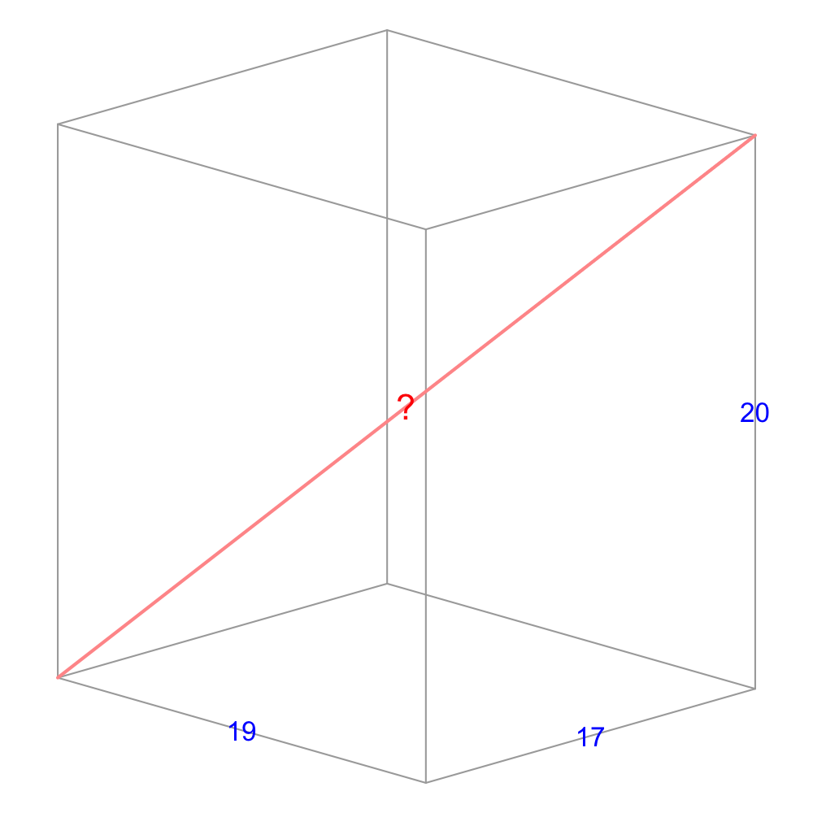

Please be accurate within $\pm$ 0.01 of the exact answer.

Let's use Pythagorean Theorem. This is possible because all angles are 90 degrees. To do this, we can first find the length of a diagonal across the bottom. Let's call it $B$.

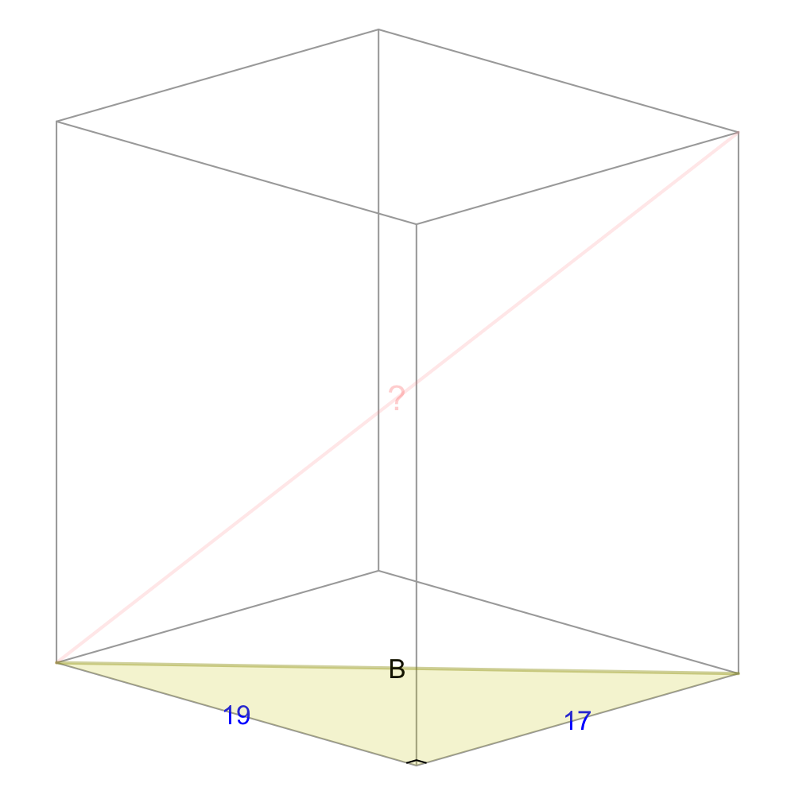

$$B~=~\sqrt{17^2+19^2}~=~\sqrt{650}
~\approx~25.4950976$$

Now we can form another **right triangle**, using $B$, the height, and the desired length, which we can call $D$.

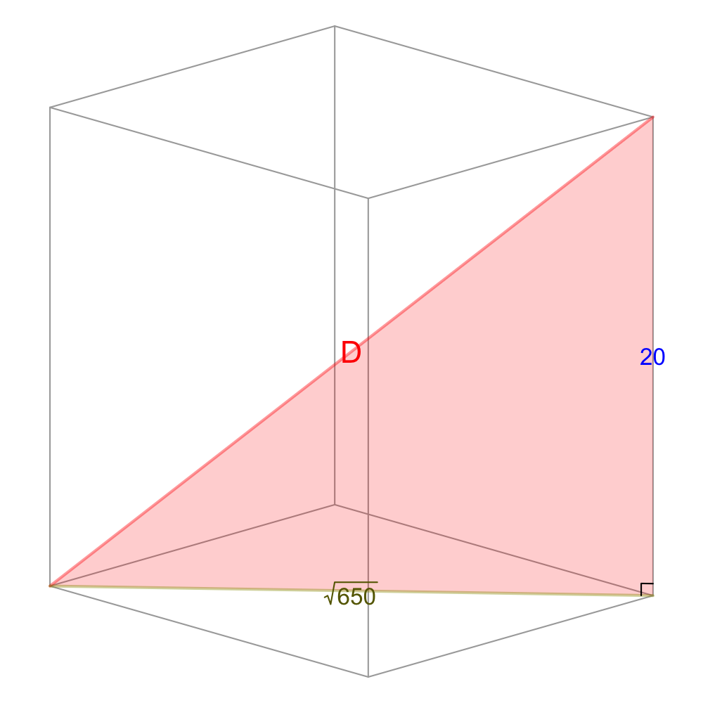

$$D ~=~
\sqrt{20^2+\left(\sqrt{650}\right)^2}$$
$$D ~=~ \sqrt{400+650}$$
$$D ~=~ \sqrt{1050}$$
$$D ~\approx~ 32.4037035$$

If you were super observant, you might have picked up on a shortcut. Basically, in 3D, [the distance](https://en.wikipedia.org/wiki/Distance#Straight-line_or_Euclidean_distance) between 2 points is:

$$D~=~\sqrt{(\Delta x)^2+(\Delta
y)^2+(\Delta z)^2}$$

where $\Delta x=x_2-x_1$ and $\Delta y=y_2-y_1$ and $\Delta z=z_2-z_1$.

A circle is the collection of points equally distant from a center. If the circle has a center $(h,k)$ and a radius $r$, then we can represent that circle in the $xy$-plane using the following standard form of a circle:

$$(x-h)^2+(y-k)^2 = r^2$$

Notice that this equation looks like the Pythagorean Equation (from the Pythagorean Theorem): $a^2+b^2=c^2$. It also looks like the distance formula, were $r$ is the distance, $x-h$ is the horizontal displacement, and $y-k$ is the vertical displacement.

Consider the circle graphed below. Some of the points on the circle are $(-6,9)$, $(-10,13)$, $(-14,9)$, and $(-10,5)$.

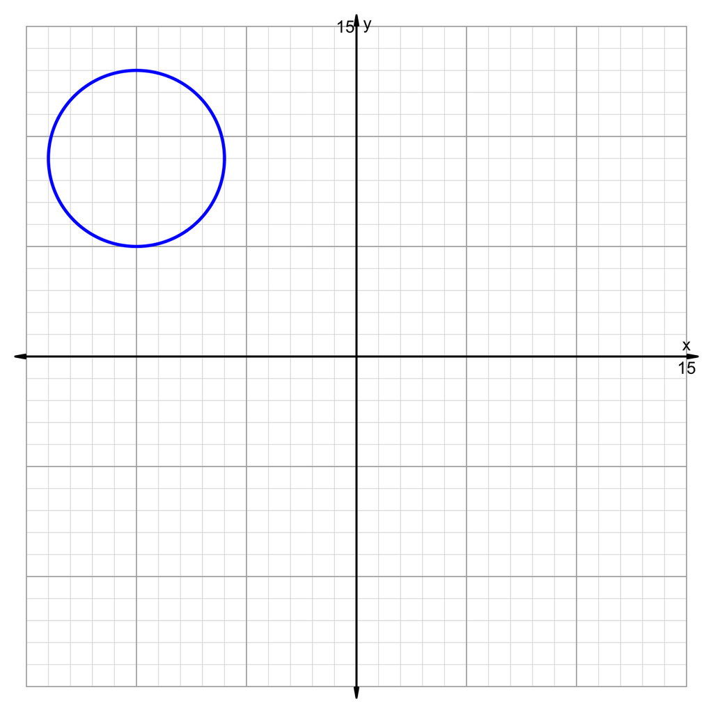

Find the values of the parameters $h$, $k$, and $r$.

- $h=$
- $k=$
- $r=$

The center of the circle is at $(-10, 9)$, so $h=-10$ and $k=9$. The radius of the circle is the distance from the center to the edge. The radius is 4, so $r=4$.

The standard equation of the circle is shown:

$$(x+10)^2+(y-9)^2=4^2$$

A circle is the collection of points equally distant from a center. If the circle has a center $(h,k)$ and a radius $r$, then we can represent that circle in the $xy$-plane using the following standard form of a circle:

$$(x-h)^2+(y-k)^2 = r^2$$

Notice that this equation looks like the Pythagorean Equation (from the Pythagorean Theorem): $a^2+b^2=c^2$. It also looks like the distance formula, were $r$ is the distance, $x-h$ is the horizontal displacement, and $y-k$ is the vertical displacement.

Consider the circle graphed below. Some of the points on the circle are $(-4,2)$, $(-7,5)$, $(-10,2)$, and $(-7,-1)$.

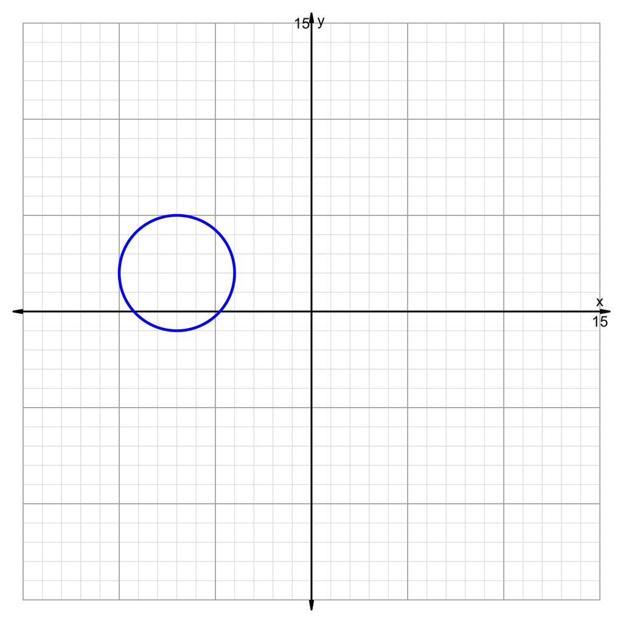

Find the values of the parameters $h$, $k$, and $r$.

- $h=$
- $k=$
- $r=$

The center of the circle is at $(-7, 2)$, so $h=-7$ and $k=2$. The radius of the circle is the distance from the center to the edge. The radius is 3, so $r=3$.

The standard equation of the circle is shown:

$$(x+7)^2+(y-2)^2=3^2$$

A circle is the collection of points equally distant from a center. If the circle has a center $(h,k)$ and a radius $r$, then we can represent that circle in the $xy$-plane using the following standard form of a circle:

$$(x-h)^2+(y-k)^2 = r^2$$

Notice that this equation looks like the Pythagorean Equation (from the Pythagorean Theorem): $a^2+b^2=c^2$. It also looks like the distance formula, were $r$ is the distance, $x-h$ is the horizontal displacement, and $y-k$ is the vertical displacement.

Consider the circle graphed below. Some of the points on the circle are $(1,-9)$, $(-3,-5)$, $(-7,-9)$, and $(-3,-13)$.

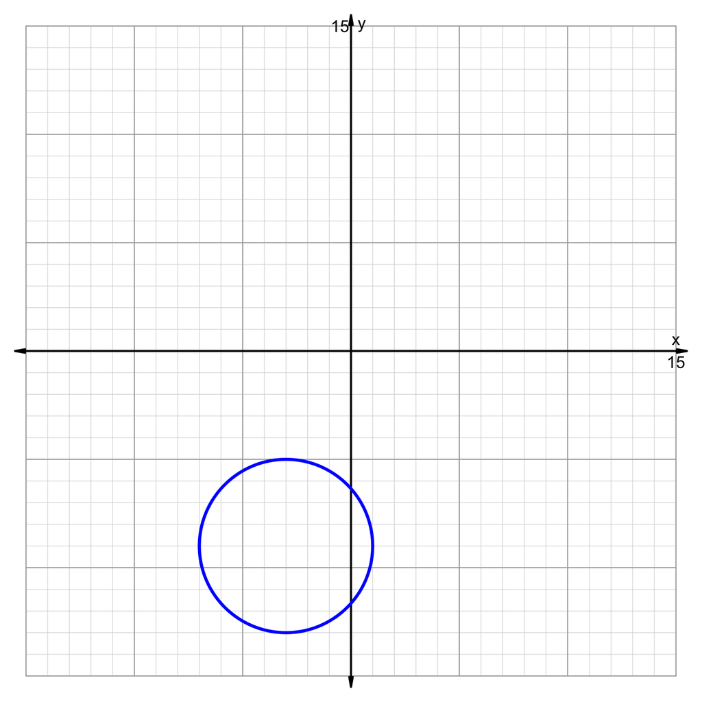

Find the values of the parameters $h$, $k$, and $r$.

- $h=$
- $k=$
- $r=$

The center of the circle is at $(-3, -9)$, so $h=-3$ and $k=-9$. The radius of the circle is the distance from the center to the edge. The radius is 4, so $r=4$.

The standard equation of the circle is shown:

$$(x+3)^2+(y+9)^2=4^2$$

A circle is the collection of points equally distant from a center. If the circle has a center $(h,k)$ and a radius $r$, then we can represent that circle in the $xy$-plane using the following standard form of a circle:

$$(x-h)^2+(y-k)^2 = r^2$$

Notice that this equation looks like the Pythagorean Equation (from the Pythagorean Theorem): $a^2+b^2=c^2$. It also looks like the distance formula, were $r$ is the distance, $x-h$ is the horizontal displacement, and $y-k$ is the vertical displacement.

Consider the circle graphed below. Some of the points on the circle are $(3,-6)$, $(-4,1)$, $(-11,-6)$, and $(-4,-13)$.

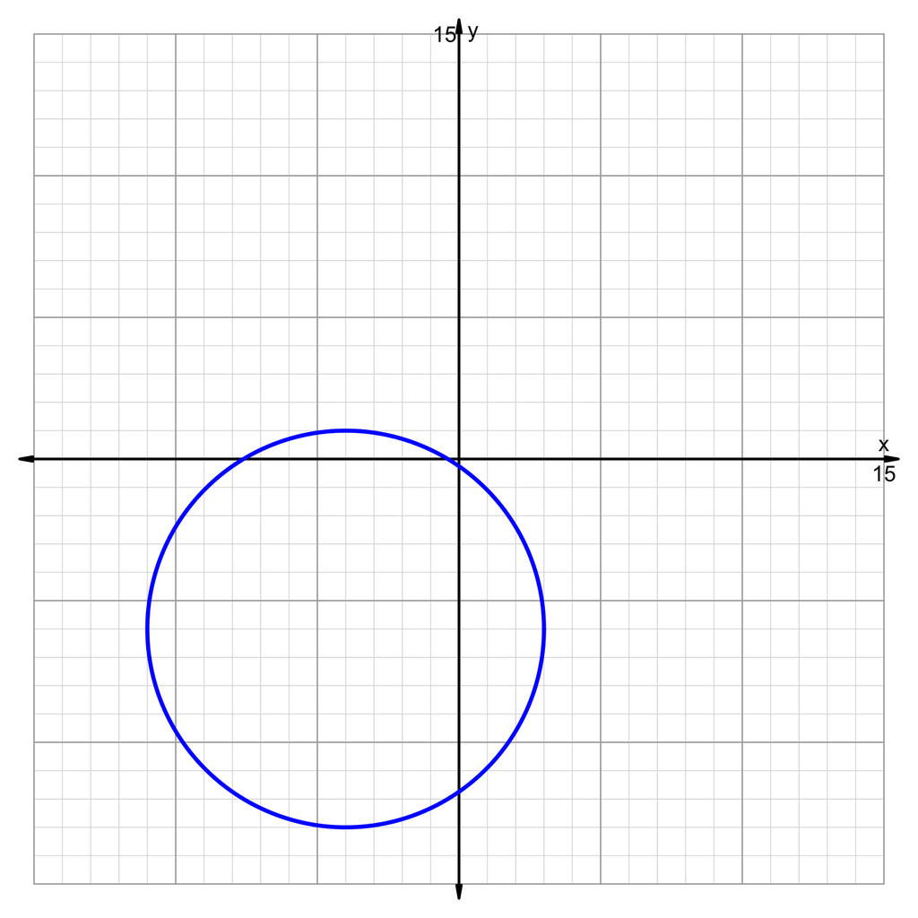

Find the values of the parameters $h$, $k$, and $r$.

- $h=$
- $k=$
- $r=$

The center of the circle is at $(-4, -6)$, so $h=-4$ and $k=-6$. The radius of the circle is the distance from the center to the edge. The radius is 7, so $r=7$.

The standard equation of the circle is shown:

$$(x+4)^2+(y+6)^2=7^2$$

A circle is the collection of points equally distant from a center. If the circle has a center $(h,k)$ and a radius $r$, then we can represent that circle in the $xy$-plane using the following standard form of a circle:

$$(x-h)^2+(y-k)^2 = r^2$$

Notice that this equation looks like the Pythagorean Equation (from the Pythagorean Theorem): $a^2+b^2=c^2$. It also looks like the distance formula, were $r$ is the distance, $x-h$ is the horizontal displacement, and $y-k$ is the vertical displacement.

Consider the circle graphed below. Some of the points on the circle are $(-2,-7)$, $(-6,-3)$, $(-10,-7)$, and $(-6,-11)$.

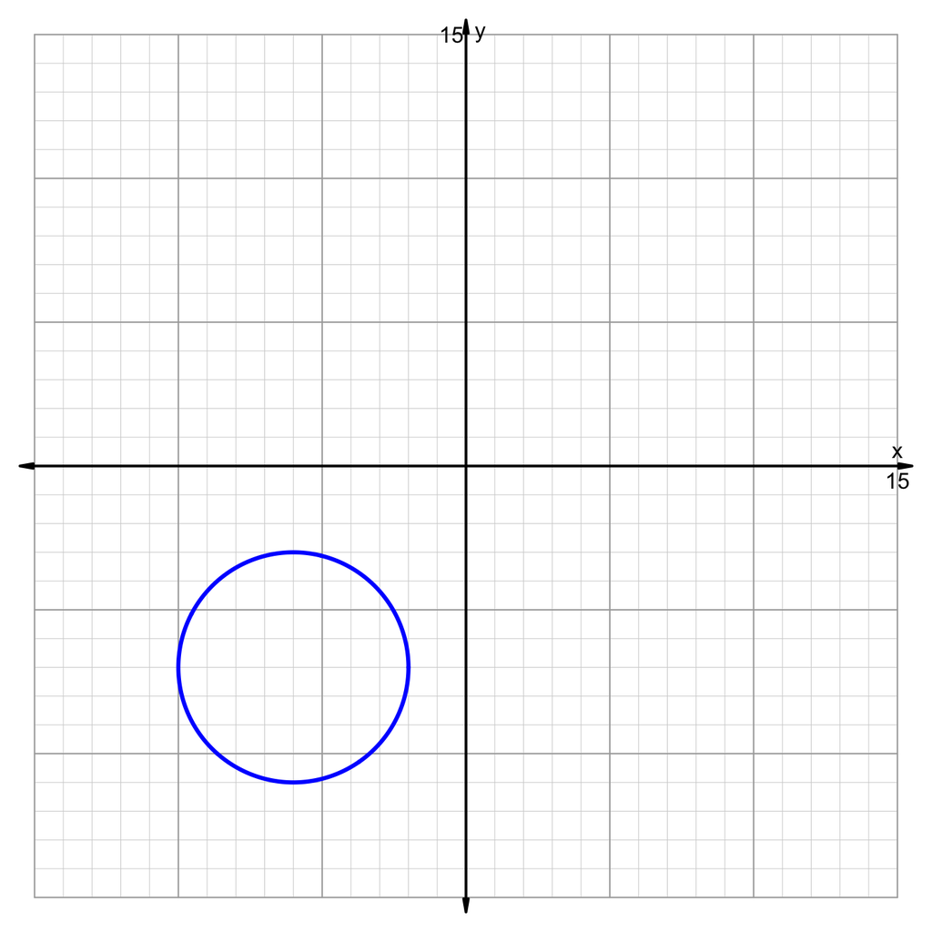

Find the values of the parameters $h$, $k$, and $r$.

- $h=$
- $k=$
- $r=$

The center of the circle is at $(-6, -7)$, so $h=-6$ and $k=-7$. The radius of the circle is the distance from the center to the edge. The radius is 4, so $r=4$.

The standard equation of the circle is shown:

$$(x+6)^2+(y+7)^2=4^2$$

A circle is the collection of points equally distant from a center. If the circle has a center $(h,k)$ and a radius $r$, then we can represent that circle in the $xy$-plane using the following standard form of a circle:

$$(x-h)^2+(y-k)^2 = r^2$$

Notice that this equation looks like the Pythagorean Equation (from the Pythagorean Theorem): $a^2+b^2=c^2$. It also looks like the distance formula, were $r$ is the distance, $x-h$ is the horizontal displacement, and $y-k$ is the vertical displacement.

Consider the circle graphed below. Some of the points on the circle are $(11,-6)$, $(3,2)$, $(-5,-6)$, and $(3,-14)$.

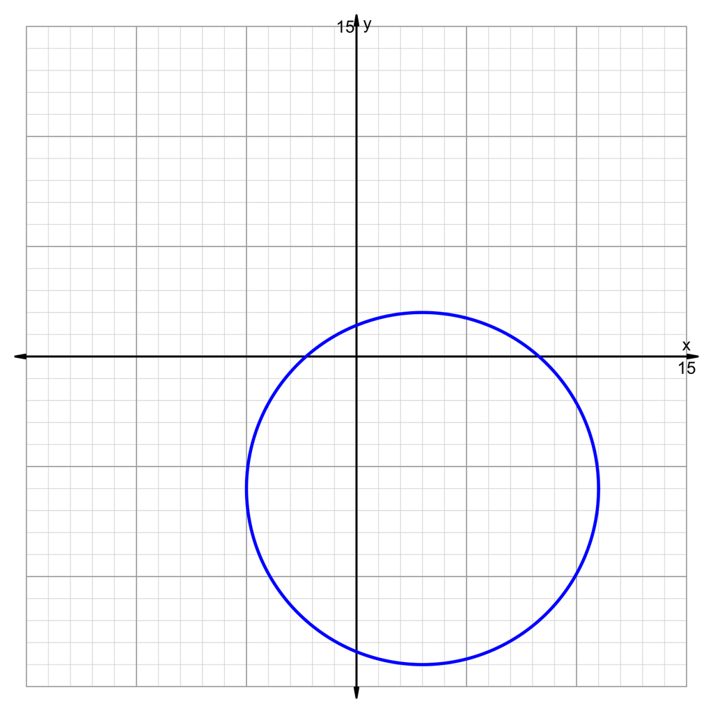

Find the values of the parameters $h$, $k$, and $r$.

- $h=$
- $k=$
- $r=$

The center of the circle is at $(3, -6)$, so $h=3$ and $k=-6$. The radius of the circle is the distance from the center to the edge. The radius is 8, so $r=8$.

The standard equation of the circle is shown:

$$(x-3)^2+(y+6)^2=8^2$$

A circle is the collection of points equally distant from a center. If the circle has a center $(h,k)$ and a radius $r$, then we can represent that circle in the $xy$-plane using the following standard form of a circle:

$$(x-h)^2+(y-k)^2 = r^2$$

Notice that this equation looks like the Pythagorean Equation (from the Pythagorean Theorem): $a^2+b^2=c^2$. It also looks like the distance formula, were $r$ is the distance, $x-h$ is the horizontal displacement, and $y-k$ is the vertical displacement.

Consider the circle graphed below. Some of the points on the circle are $(14,-11)$, $(12,-9)$, $(10,-11)$, and $(12,-13)$.

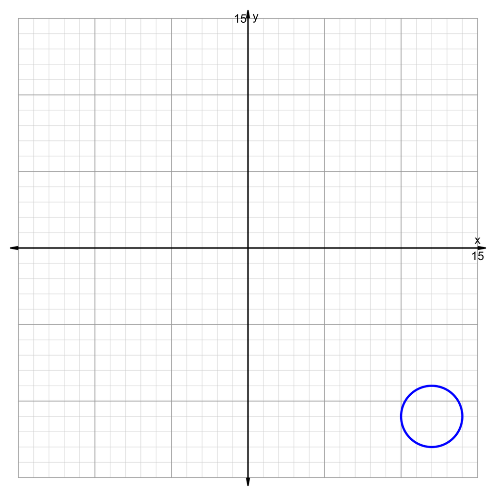

Find the values of the parameters $h$, $k$, and $r$.

- $h=$
- $k=$
- $r=$

The center of the circle is at $(12, -11)$, so $h=12$ and $k=-11$. The radius of the circle is the distance from the center to the edge. The radius is 2, so $r=2$.

The standard equation of the circle is shown:

$$(x-12)^2+(y+11)^2=2^2$$

A circle is the collection of points equally distant from a center. If the circle has a center $(h,k)$ and a radius $r$, then we can represent that circle in the $xy$-plane using the following standard form of a circle:

$$(x-h)^2+(y-k)^2 = r^2$$

Notice that this equation looks like the Pythagorean Equation (from the Pythagorean Theorem): $a^2+b^2=c^2$. It also looks like the distance formula, were $r$ is the distance, $x-h$ is the horizontal displacement, and $y-k$ is the vertical displacement.

Consider the circle graphed below. Some of the points on the circle are $(7,10)$, $(4,13)$, $(1,10)$, and $(4,7)$.

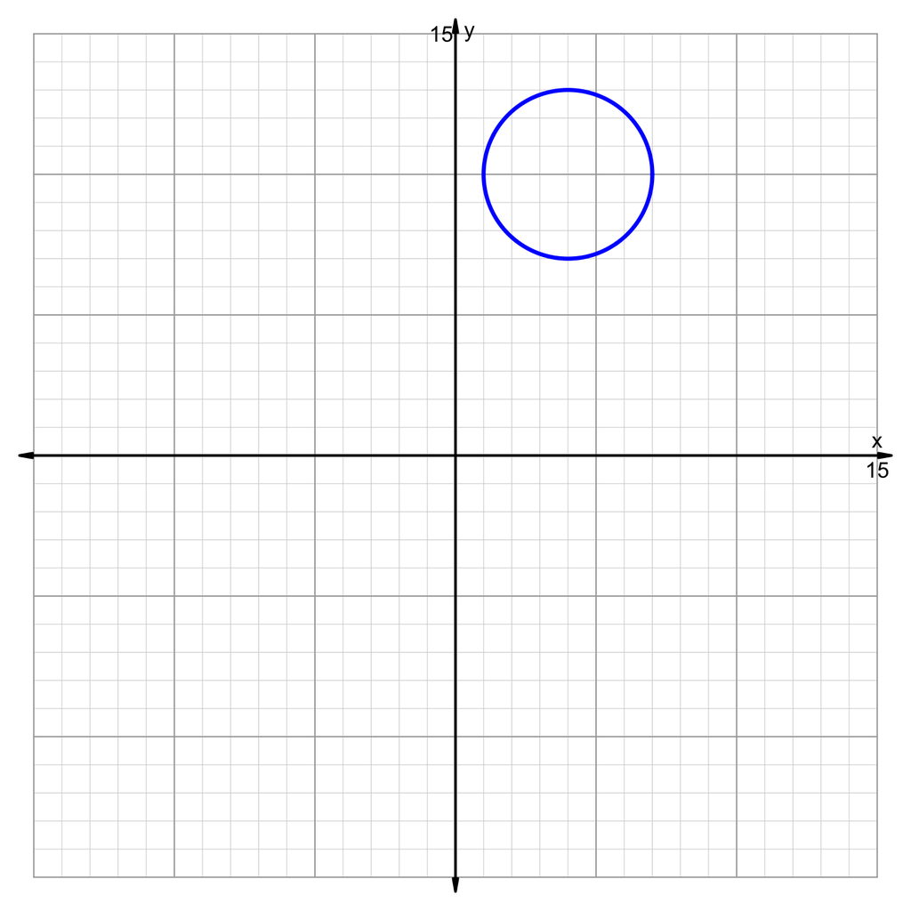

Find the values of the parameters $h$, $k$, and $r$.

- $h=$
- $k=$
- $r=$

The center of the circle is at $(4, 10)$, so $h=4$ and $k=10$. The radius of the circle is the distance from the center to the edge. The radius is 3, so $r=3$.

The standard equation of the circle is shown:

$$(x-4)^2+(y-10)^2=3^2$$

A circle is the collection of points equally distant from a center. If the circle has a center $(h,k)$ and a radius $r$, then we can represent that circle in the $xy$-plane using the following standard form of a circle:

$$(x-h)^2+(y-k)^2 = r^2$$

Notice that this equation looks like the Pythagorean Equation (from the Pythagorean Theorem): $a^2+b^2=c^2$. It also looks like the distance formula, were $r$ is the distance, $x-h$ is the horizontal displacement, and $y-k$ is the vertical displacement.

Consider the circle graphed below. Some of the points on the circle are $(-10,-7)$, $(-12,-5)$, $(-14,-7)$, and $(-12,-9)$.

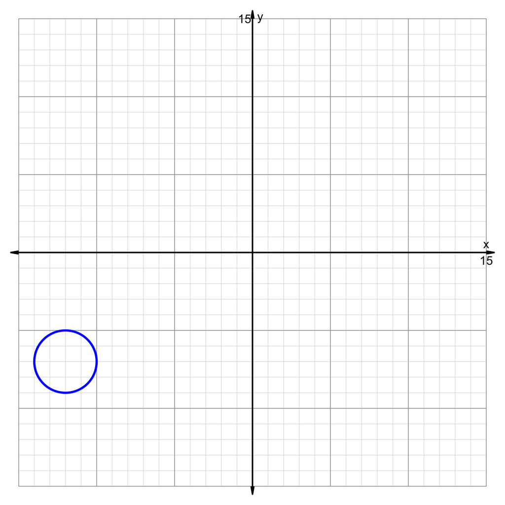

Find the values of the parameters $h$, $k$, and $r$.

- $h=$
- $k=$
- $r=$

The center of the circle is at $(-12, -7)$, so $h=-12$ and $k=-7$. The radius of the circle is the distance from the center to the edge. The radius is 2, so $r=2$.

The standard equation of the circle is shown:

$$(x+12)^2+(y+7)^2=2^2$$

A circle is the collection of points equally distant from a center. If the circle has a center $(h,k)$ and a radius $r$, then we can represent that circle in the $xy$-plane using the following standard form of a circle:

$$(x-h)^2+(y-k)^2 = r^2$$

Notice that this equation looks like the Pythagorean Equation (from the Pythagorean Theorem): $a^2+b^2=c^2$. It also looks like the distance formula, were $r$ is the distance, $x-h$ is the horizontal displacement, and $y-k$ is the vertical displacement.

Consider the circle graphed below. Some of the points on the circle are $(11,8)$, $(5,14)$, $(-1,8)$, and $(5,2)$.

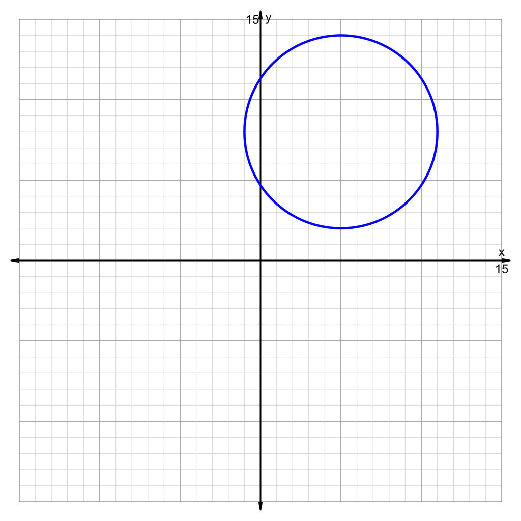

Find the values of the parameters $h$, $k$, and $r$.

- $h=$
- $k=$
- $r=$

The center of the circle is at $(5, 8)$, so $h=5$ and $k=8$. The radius of the circle is the distance from the center to the edge. The radius is 6, so $r=6$.

The standard equation of the circle is shown:

$$(x-5)^2+(y-8)^2=6^2$$

The following equation produces a circle.

$$(x+5)^2+(y-3)^2=100$$

That circle has a center point, $(h,k)$, and radius, $r$.

Find the values of the parameters $h$, $k$, and $r$.

- $h=$
- $k=$
- $r=$

The standard form of a circle at center $(h,k)$ with radius $r$ is:

$$(x-h)^2+(y-k)^2=r^2$$

The given equation:

$$(x+5)^2+(y-3)^2=100$$

With a bit of rearrangement:

$$\left(x-(-5)\right)^2+\left(y-(3)\right)^2=10^2$$

- $h=-5$
- $k=3$
- $r=10$

The following equation produces a circle.

$$(x-5)^2+(y+8)^2=144$$

That circle has a center point, $(h,k)$, and radius, $r$.

Find the values of the parameters $h$, $k$, and $r$.

- $h=$
- $k=$
- $r=$

The standard form of a circle at center $(h,k)$ with radius $r$ is:

$$(x-h)^2+(y-k)^2=r^2$$

The given equation:

$$(x-5)^2+(y+8)^2=144$$

With a bit of rearrangement:

$$\left(x-(5)\right)^2+\left(y-(-8)\right)^2=12^2$$

- $h=5$
- $k=-8$
- $r=12$

The following equation produces a circle.

$$(x-12)^2+(y+6)^2=121$$

That circle has a center point, $(h,k)$, and radius, $r$.

Find the values of the parameters $h$, $k$, and $r$.

- $h=$
- $k=$
- $r=$

The standard form of a circle at center $(h,k)$ with radius $r$ is:

$$(x-h)^2+(y-k)^2=r^2$$

The given equation:

$$(x-12)^2+(y+6)^2=121$$

With a bit of rearrangement:

$$\left(x-(12)\right)^2+\left(y-(-6)\right)^2=11^2$$

- $h=12$
- $k=-6$
- $r=11$

The following equation produces a circle.

$$(x-12)^2+(y+11)^2=25$$

That circle has a center point, $(h,k)$, and radius, $r$.

Find the values of the parameters $h$, $k$, and $r$.

- $h=$
- $k=$
- $r=$

The standard form of a circle at center $(h,k)$ with radius $r$ is:

$$(x-h)^2+(y-k)^2=r^2$$

The given equation:

$$(x-12)^2+(y+11)^2=25$$

With a bit of rearrangement:

$$\left(x-(12)\right)^2+\left(y-(-11)\right)^2=5^2$$

- $h=12$
- $k=-11$
- $r=5$

The following equation produces a circle.

$$(x+11)^2+(y-8)^2=9$$

That circle has a center point, $(h,k)$, and radius, $r$.

Find the values of the parameters $h$, $k$, and $r$.

- $h=$
- $k=$
- $r=$

The standard form of a circle at center $(h,k)$ with radius $r$ is:

$$(x-h)^2+(y-k)^2=r^2$$

The given equation:

$$(x+11)^2+(y-8)^2=9$$

With a bit of rearrangement:

$$\left(x-(-11)\right)^2+\left(y-(8)\right)^2=3^2$$

- $h=-11$
- $k=8$
- $r=3$

The following equation produces a circle.

$$(x-5)^2+(y+7)^2=100$$

That circle has a center point, $(h,k)$, and radius, $r$.

Find the values of the parameters $h$, $k$, and $r$.

- $h=$
- $k=$
- $r=$

The standard form of a circle at center $(h,k)$ with radius $r$ is:

$$(x-h)^2+(y-k)^2=r^2$$

The given equation:

$$(x-5)^2+(y+7)^2=100$$

With a bit of rearrangement:

$$\left(x-(5)\right)^2+\left(y-(-7)\right)^2=10^2$$

- $h=5$
- $k=-7$
- $r=10$

The following equation produces a circle.

$$(x-8)^2+(y+6)^2=81$$

That circle has a center point, $(h,k)$, and radius, $r$.

Find the values of the parameters $h$, $k$, and $r$.

- $h=$
- $k=$
- $r=$

The standard form of a circle at center $(h,k)$ with radius $r$ is:

$$(x-h)^2+(y-k)^2=r^2$$

The given equation:

$$(x-8)^2+(y+6)^2=81$$

With a bit of rearrangement:

$$\left(x-(8)\right)^2+\left(y-(-6)\right)^2=9^2$$

- $h=8$
- $k=-6$
- $r=9$

The following equation produces a circle.

$$(x-7)^2+(y+11)^2=36$$

That circle has a center point, $(h,k)$, and radius, $r$.

Find the values of the parameters $h$, $k$, and $r$.

- $h=$
- $k=$
- $r=$

The standard form of a circle at center $(h,k)$ with radius $r$ is:

$$(x-h)^2+(y-k)^2=r^2$$

The given equation:

$$(x-7)^2+(y+11)^2=36$$

With a bit of rearrangement:

$$\left(x-(7)\right)^2+\left(y-(-11)\right)^2=6^2$$

- $h=7$
- $k=-11$
- $r=6$

The following equation produces a circle.

$$(x-11)^2+(y+12)^2=49$$

That circle has a center point, $(h,k)$, and radius, $r$.

Find the values of the parameters $h$, $k$, and $r$.

- $h=$
- $k=$
- $r=$

The standard form of a circle at center $(h,k)$ with radius $r$ is:

$$(x-h)^2+(y-k)^2=r^2$$

The given equation:

$$(x-11)^2+(y+12)^2=49$$

With a bit of rearrangement:

$$\left(x-(11)\right)^2+\left(y-(-12)\right)^2=7^2$$

- $h=11$
- $k=-12$
- $r=7$

The following equation produces a circle.

$$(x-4)^2+(y+10)^2=81$$

That circle has a center point, $(h,k)$, and radius, $r$.

Find the values of the parameters $h$, $k$, and $r$.

- $h=$
- $k=$
- $r=$

The standard form of a circle at center $(h,k)$ with radius $r$ is:

$$(x-h)^2+(y-k)^2=r^2$$

The given equation:

$$(x-4)^2+(y+10)^2=81$$

With a bit of rearrangement:

$$\left(x-(4)\right)^2+\left(y-(-10)\right)^2=9^2$$

- $h=4$
- $k=-10$
- $r=9$

When plotting all $x$-$y$ pairs that satisfy the given equation (make the equation true), the result is a circle.

$$x^2+10x+y^2-12y~=~-12$$

The standard form of an equation of a circle shows the center $(h,k)$ and radius $r$ as parameters.

$$(x-h)^2+(y-k)^2~=~r^2$$

In order to convert the given circle into standard form, you should [complete the square](https://en.wikipedia.org/wiki/Completing_the_square) (twice, once for $x$-containing terms and once for $y$-containing terms). After you convert the equation to standard form, indicate the values of the parameters.

- $h=$
- $k=$
- $r=$

The given equation:

$$x^2+10x+y^2-12y~=~-12$$

Determine the constants needed for perfect squares. Do this by halving the linear coefficient and squaring the result. In other words, $z^2+bz+\left(\frac{b}{2}\right)^2$ is a perfect square for any value of $b$.

$$x^2+10x+25+y^2-12y+36~=~-12+25+36$$

Write each perfect square in factored form. Also, simplify the right side.

$$(x+5)^2+(y-6)^2~=~49$$

Notice $49$ is a perfect square integer.

$$(x+5)^2+(y-6)^2~=~7^2$$

Thus,

$$h=-5$$
$$k=6$$
$$r=7$$

When plotting all $x$-$y$ pairs that satisfy the given equation (make the equation true), the result is a circle.

$$x^2+4x+y^2+14y~=~-17$$

The standard form of an equation of a circle shows the center $(h,k)$ and radius $r$ as parameters.

$$(x-h)^2+(y-k)^2~=~r^2$$

In order to convert the given circle into standard form, you should [complete the square](https://en.wikipedia.org/wiki/Completing_the_square) (twice, once for $x$-containing terms and once for $y$-containing terms). After you convert the equation to standard form, indicate the values of the parameters.

- $h=$
- $k=$
- $r=$

The given equation:

$$x^2+4x+y^2+14y~=~-17$$

Determine the constants needed for perfect squares. Do this by halving the linear coefficient and squaring the result. In other words, $z^2+bz+\left(\frac{b}{2}\right)^2$ is a perfect square for any value of $b$.

$$x^2+4x+4+y^2+14y+49~=~-17+4+49$$

Write each perfect square in factored form. Also, simplify the right side.

$$(x+2)^2+(y+7)^2~=~36$$

Notice $36$ is a perfect square integer.

$$(x+2)^2+(y+7)^2~=~6^2$$

Thus,

$$h=-2$$
$$k=-7$$
$$r=6$$

When plotting all $x$-$y$ pairs that satisfy the given equation (make the equation true), the result is a circle.

$$x^2+16x+y^2+18y~=~-129$$

The standard form of an equation of a circle shows the center $(h,k)$ and radius $r$ as parameters.

$$(x-h)^2+(y-k)^2~=~r^2$$

In order to convert the given circle into standard form, you should [complete the square](https://en.wikipedia.org/wiki/Completing_the_square) (twice, once for $x$-containing terms and once for $y$-containing terms). After you convert the equation to standard form, indicate the values of the parameters.

- $h=$
- $k=$
- $r=$

The given equation:

$$x^2+16x+y^2+18y~=~-129$$

Determine the constants needed for perfect squares. Do this by halving the linear coefficient and squaring the result. In other words, $z^2+bz+\left(\frac{b}{2}\right)^2$ is a perfect square for any value of $b$.

$$x^2+16x+64+y^2+18y+81~=~-129+64+81$$

Write each perfect square in factored form. Also, simplify the right side.

$$(x+8)^2+(y+9)^2~=~16$$

Notice $16$ is a perfect square integer.

$$(x+8)^2+(y+9)^2~=~4^2$$

Thus,

$$h=-8$$
$$k=-9$$
$$r=4$$

When plotting all $x$-$y$ pairs that satisfy the given equation (make the equation true), the result is a circle.

$$x^2-8x+y^2-4y~=~-11$$

The standard form of an equation of a circle shows the center $(h,k)$ and radius $r$ as parameters.

$$(x-h)^2+(y-k)^2~=~r^2$$

In order to convert the given circle into standard form, you should [complete the square](https://en.wikipedia.org/wiki/Completing_the_square) (twice, once for $x$-containing terms and once for $y$-containing terms). After you convert the equation to standard form, indicate the values of the parameters.

- $h=$
- $k=$
- $r=$

The given equation:

$$x^2-8x+y^2-4y~=~-11$$

Determine the constants needed for perfect squares. Do this by halving the linear coefficient and squaring the result. In other words, $z^2+bz+\left(\frac{b}{2}\right)^2$ is a perfect square for any value of $b$.

$$x^2-8x+16+y^2-4y+4~=~-11+16+4$$

Write each perfect square in factored form. Also, simplify the right side.

$$(x-4)^2+(y-2)^2~=~9$$

Notice $9$ is a perfect square integer.

$$(x-4)^2+(y-2)^2~=~3^2$$

Thus,

$$h=4$$
$$k=2$$
$$r=3$$

When plotting all $x$-$y$ pairs that satisfy the given equation (make the equation true), the result is a circle.

$$x^2-8x+y^2-12y~=~-48$$

The standard form of an equation of a circle shows the center $(h,k)$ and radius $r$ as parameters.

$$(x-h)^2+(y-k)^2~=~r^2$$

In order to convert the given circle into standard form, you should [complete the square](https://en.wikipedia.org/wiki/Completing_the_square) (twice, once for $x$-containing terms and once for $y$-containing terms). After you convert the equation to standard form, indicate the values of the parameters.

- $h=$
- $k=$
- $r=$

The given equation:

$$x^2-8x+y^2-12y~=~-48$$

Determine the constants needed for perfect squares. Do this by halving the linear coefficient and squaring the result. In other words, $z^2+bz+\left(\frac{b}{2}\right)^2$ is a perfect square for any value of $b$.

$$x^2-8x+16+y^2-12y+36~=~-48+16+36$$

Write each perfect square in factored form. Also, simplify the right side.

$$(x-4)^2+(y-6)^2~=~4$$

Notice $4$ is a perfect square integer.

$$(x-4)^2+(y-6)^2~=~2^2$$

Thus,

$$h=4$$
$$k=6$$
$$r=2$$

When plotting all $x$-$y$ pairs that satisfy the given equation (make the equation true), the result is a circle.

$$x^2+16x+y^2-4y~=~-19$$

The standard form of an equation of a circle shows the center $(h,k)$ and radius $r$ as parameters.

$$(x-h)^2+(y-k)^2~=~r^2$$

In order to convert the given circle into standard form, you should [complete the square](https://en.wikipedia.org/wiki/Completing_the_square) (twice, once for $x$-containing terms and once for $y$-containing terms). After you convert the equation to standard form, indicate the values of the parameters.

- $h=$
- $k=$
- $r=$

The given equation:

$$x^2+16x+y^2-4y~=~-19$$

Determine the constants needed for perfect squares. Do this by halving the linear coefficient and squaring the result. In other words, $z^2+bz+\left(\frac{b}{2}\right)^2$ is a perfect square for any value of $b$.

$$x^2+16x+64+y^2-4y+4~=~-19+64+4$$

Write each perfect square in factored form. Also, simplify the right side.

$$(x+8)^2+(y-2)^2~=~49$$

Notice $49$ is a perfect square integer.

$$(x+8)^2+(y-2)^2~=~7^2$$

Thus,

$$h=-8$$
$$k=2$$
$$r=7$$

When plotting all $x$-$y$ pairs that satisfy the given equation (make the equation true), the result is a circle.

$$x^2-16x+y^2+6y~=~-57$$

The standard form of an equation of a circle shows the center $(h,k)$ and radius $r$ as parameters.

$$(x-h)^2+(y-k)^2~=~r^2$$

In order to convert the given circle into standard form, you should [complete the square](https://en.wikipedia.org/wiki/Completing_the_square) (twice, once for $x$-containing terms and once for $y$-containing terms). After you convert the equation to standard form, indicate the values of the parameters.

- $h=$
- $k=$
- $r=$

The given equation:

$$x^2-16x+y^2+6y~=~-57$$

Determine the constants needed for perfect squares. Do this by halving the linear coefficient and squaring the result. In other words, $z^2+bz+\left(\frac{b}{2}\right)^2$ is a perfect square for any value of $b$.

$$x^2-16x+64+y^2+6y+9~=~-57+64+9$$

Write each perfect square in factored form. Also, simplify the right side.

$$(x-8)^2+(y+3)^2~=~16$$

Notice $16$ is a perfect square integer.

$$(x-8)^2+(y+3)^2~=~4^2$$

Thus,

$$h=8$$
$$k=-3$$
$$r=4$$

When plotting all $x$-$y$ pairs that satisfy the given equation (make the equation true), the result is a circle.

$$x^2+10x+y^2-4y~=~20$$

The standard form of an equation of a circle shows the center $(h,k)$ and radius $r$ as parameters.

$$(x-h)^2+(y-k)^2~=~r^2$$

In order to convert the given circle into standard form, you should [complete the square](https://en.wikipedia.org/wiki/Completing_the_square) (twice, once for $x$-containing terms and once for $y$-containing terms). After you convert the equation to standard form, indicate the values of the parameters.

- $h=$
- $k=$
- $r=$

The given equation:

$$x^2+10x+y^2-4y~=~20$$

Determine the constants needed for perfect squares. Do this by halving the linear coefficient and squaring the result. In other words, $z^2+bz+\left(\frac{b}{2}\right)^2$ is a perfect square for any value of $b$.

$$x^2+10x+25+y^2-4y+4~=~20+25+4$$

Write each perfect square in factored form. Also, simplify the right side.

$$(x+5)^2+(y-2)^2~=~49$$

Notice $49$ is a perfect square integer.

$$(x+5)^2+(y-2)^2~=~7^2$$

Thus,

$$h=-5$$
$$k=2$$
$$r=7$$

When plotting all $x$-$y$ pairs that satisfy the given equation (make the equation true), the result is a circle.

$$x^2-6x+y^2+18y~=~-26$$

The standard form of an equation of a circle shows the center $(h,k)$ and radius $r$ as parameters.

$$(x-h)^2+(y-k)^2~=~r^2$$

In order to convert the given circle into standard form, you should [complete the square](https://en.wikipedia.org/wiki/Completing_the_square) (twice, once for $x$-containing terms and once for $y$-containing terms). After you convert the equation to standard form, indicate the values of the parameters.

- $h=$
- $k=$
- $r=$

The given equation:

$$x^2-6x+y^2+18y~=~-26$$

Determine the constants needed for perfect squares. Do this by halving the linear coefficient and squaring the result. In other words, $z^2+bz+\left(\frac{b}{2}\right)^2$ is a perfect square for any value of $b$.

$$x^2-6x+9+y^2+18y+81~=~-26+9+81$$

Write each perfect square in factored form. Also, simplify the right side.

$$(x-3)^2+(y+9)^2~=~64$$

Notice $64$ is a perfect square integer.

$$(x-3)^2+(y+9)^2~=~8^2$$

Thus,

$$h=3$$
$$k=-9$$
$$r=8$$

When plotting all $x$-$y$ pairs that satisfy the given equation (make the equation true), the result is a circle.

$$x^2+12x+y^2-10y~=~3$$

The standard form of an equation of a circle shows the center $(h,k)$ and radius $r$ as parameters.

$$(x-h)^2+(y-k)^2~=~r^2$$

In order to convert the given circle into standard form, you should [complete the square](https://en.wikipedia.org/wiki/Completing_the_square) (twice, once for $x$-containing terms and once for $y$-containing terms). After you convert the equation to standard form, indicate the values of the parameters.

- $h=$
- $k=$
- $r=$

The given equation:

$$x^2+12x+y^2-10y~=~3$$

Determine the constants needed for perfect squares. Do this by halving the linear coefficient and squaring the result. In other words, $z^2+bz+\left(\frac{b}{2}\right)^2$ is a perfect square for any value of $b$.

$$x^2+12x+36+y^2-10y+25~=~3+36+25$$

Write each perfect square in factored form. Also, simplify the right side.

$$(x+6)^2+(y-5)^2~=~64$$

Notice $64$ is a perfect square integer.

$$(x+6)^2+(y-5)^2~=~8^2$$

Thus,

$$h=-6$$
$$k=5$$
$$r=8$$